# Prosper Loan Data Exploration

## by Mahmoud Alaa

## Investigation Overview

We will try to investigate the prosper loan data and try to understand what can affect the Loan status and APR

## Dataset Overview

This data set contains 113,937 loans with 81 variables on each loan, including loan amount, borrower rate (or interest rate), current loan status, borrower income, and many others

### What is the frequency and percentage of Loan Status values ?

We Can see from this plot that about 50% of the Loan Status is Current it means that they have recently made a payment and 34.1% Completed their payment 10.7% Charged off and 4.5% Defaulted on their payments

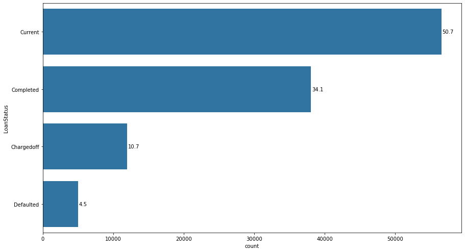

### How is the distribution of Annual Percentage Rate looks like ?

We can see that interst rate is between 0.05 and 0.40 for the most of the borrowers

There is very little number of borrowers with more the 0.4 APR

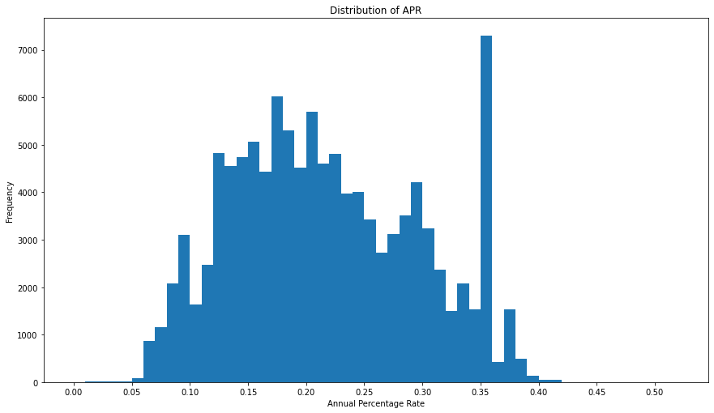

### Is ProsperRating affect the Loan status ?

The Default loans are the lower in the absolute frequency

The absolute relative frequency of The Prosper Rating increase in the Chargedoff and Defaulted loans while The absolute relative frequency of The Prosper Rating is the bigger in the current loan

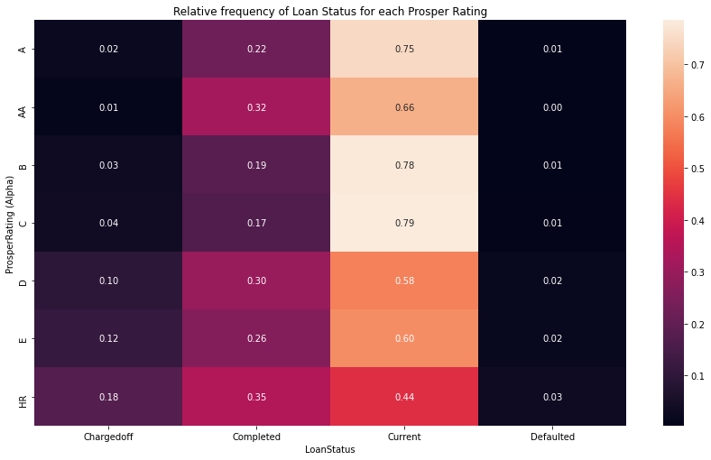

### Is Employment Status affect the Loan status ?

High porpotion of Retired and Full time employees completed their loans :

58 % of Retired empolyees have completed their Loans

66 % of Full time empolyees have completed their Loans

High porpotion of Employed and Other employees completed their loans is still current and we can see that :

75 % of Employed borrowers their loan still current

78 % of Other borrowers their loan still current

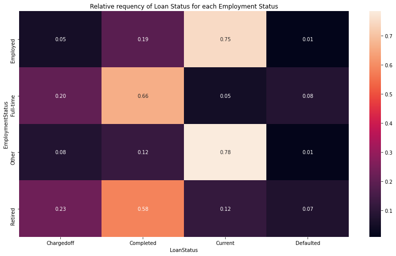

### Does the Credit Score affect Annual Percentage Rate ?

We can see if the Credit Score increases the APR decreases

For Example the credit Score which is between 800 and 850 the most Frequent APR less than 0.1

and when the credit score was between 600 and 650 the Most frequent APR was between 0.15 and 0.35

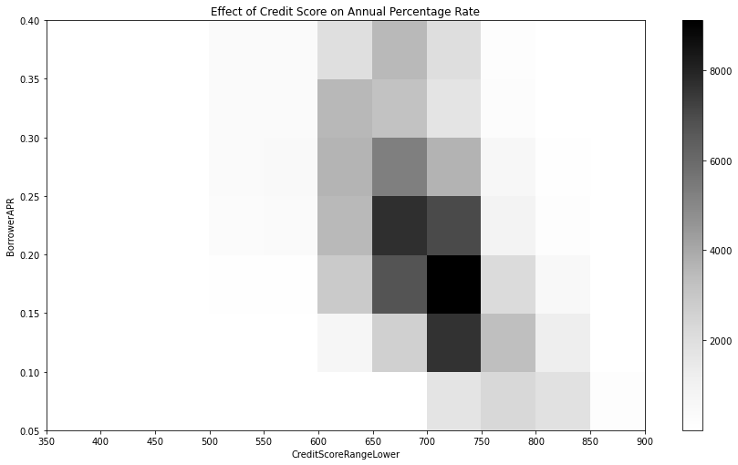

### What is the relationship between ProsperRating and Borrower Annual Percentage Rate ?

As the prosper rating which represents an estimated average annualized loss rate range to the investor increases,the APR will increase too

they have strong positive correlation

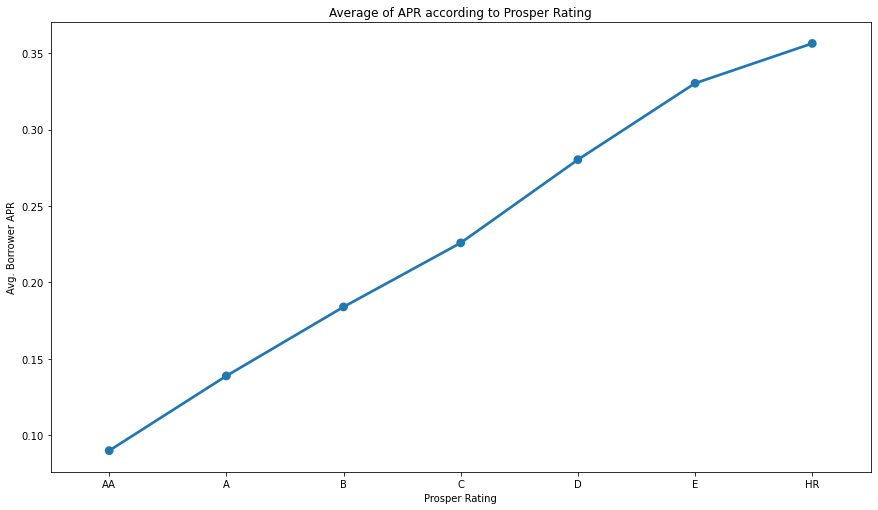

### How can Borrower APR be affected by Terms and prosper score ?

in the one year term with high prosper score we can notice lower APR compared to other terms

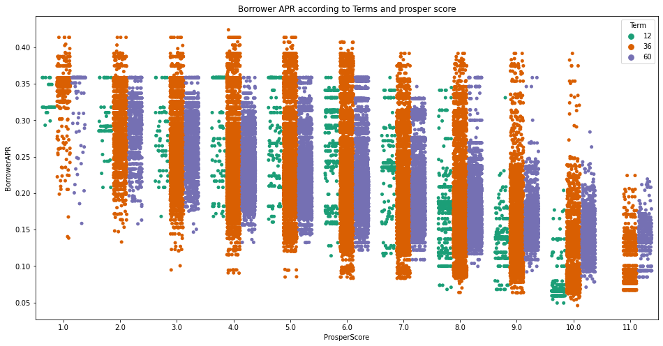